# Prueba práctica Analista de datos - Primer punto

Pragma desea empezar a trabajar con una marca que presta servicios de banca digital a otras empresas. Dicha marca tiene dentro de sus objetivos como negocio incrementar sus comisiones por utilizar su API de pago en un 50% para el 2022, ellos ganan un 5% de cada transacción que se realice a través de la APP.

Internamente saben que mucho de este crecimiento debe estar bajo estrategias de medios apoyadas en datos, por lo que Pragma le propone segmentar a sus clientes actuales (Comercios y Transacciones) para poder hacer un mejor entendimiento de quiénes son los mejores y la categoría a la que pertenecen estos, así poder crear campañas de marketing mejor segmentadas.

Para lograr esto, su reto como analista de datos es entender la información entregada, analizarla para los últimos 6 meses y lograr una segmentación de los comercios activos en ese periodo de tiempo.

El cliente le solicita que:

a. Describa el modelo de segmentación implementado y los resultados que obtuvo.

b. ¿Qué KPIs y métricas recomienda para hacer un seguimiento al cumplimiento del objetivo?

c. Haga un tablero dónde se logre visualizar el historial de las métricas y KPIs de acuerdo a la información suministrada y el resultado del modelo.

## 1. Carga de datos

```python
import pandas as pd
import numpy as np
import matplotlib.pyplot as plt
import seaborn as sns

from sklearn.preprocessing import StandardScaler
from sklearn.cluster import KMeans, AgglomerativeClustering
from sklearn.metrics import silhouette_score, davies_bouldin_score, calinski_harabasz_score
from sklearn.decomposition import PCA

sns.set_theme(style="whitegrid")
plt.rcParams["figure.figsize"] = (9, 5)
pd.set_option("display.max_columns", None)
pd.set_option("display.width", 220)
```

```python
RUTA_DATOS = "DataTransacciones_PruebasIngreso.xlsx"

xls = pd.ExcelFile(RUTA_DATOS)
df_comercios = xls.parse("comercios")
df_transacciones = xls.parse("transacciones")
```

```python
print("comercios:", df_comercios.shape)
print("transacciones:", df_transacciones.shape)
```

```
comercios: (3071, 10)
transacciones: (8357, 3)
```

```python
df_comercios.head()
```

|  | Id_comercio | Fecha vinculación datafono | Fecha de creacion comercio | Categoria comercio | Sub Categoria comercio | Id_terminal | Ciudad | Fecha 1ra_transaccion | Monto ventas Acumulado | Monto ventas ultimo mes |
| --- | --- | --- | --- | --- | --- | --- | --- | --- | --- | --- |
| 0 | 003QDVFJCJ | mar. 26, 2021 12:40pm | mar. 26, 2021 12:17pm | Comercio detallista | Ropa / Accesorios | 1299 | Bogotá D.C. | mar. 26, 2021 12:42pm | 6542000 | 1240000 |
| 1 | 008LJH6YHN | feb. 10, 2021 3:31pm | feb. 10, 2021 3:15pm | Belleza y cuidado personal | Spa | 591 | Bogotá D.C. | feb. 10, 2021 3:34pm | 4380000 | 1102000 |
| 2 | 00B3DGV62G | mar. 3, 2021 3:26pm | mar. 3, 2021 3:09pm | Comercio detallista | Auto partes | 2130 | Bogotá D.C. | mar. 3, 2021 3:30pm | 11892500 | 1297000 |
| 3 | 00ILW1BB3Y | mar. 24, 2021 12:45pm | mar. 24, 2021 12:33pm | Comercio detallista | Tienda naturista | 662 | Bogotá D.C. | mar. 24, 2021 12:51pm | 372500 | 74500 |
| 4 | 01AK7UX4UU | mar. 30, 2021 1:50pm | mar. 30, 2021 1:40pm | Comercio detallista | Tecnología | 1784 | Mosquera | mar. 30, 2021 1:52pm | 165500 | 0 |

```python
df_comercios.dtypes
```

```
Id_comercio                     str
Fecha vinculación datafono      str
Fecha de creacion comercio      str
Categoria comercio              str
Sub Categoria comercio          str
Id_terminal                   int64
Ciudad                          str
Fecha 1ra_transaccion           str
Monto ventas Acumulado        int64
Monto ventas ultimo mes       int64
dtype: object
```

```python
df_transacciones.head()
```

|  | Id_comercio | mes-anio transaccion | cantidad transacciones |
| --- | --- | --- | --- |
| 0 | 003QDVFJCJ | 3-2021 | 5 |
| 1 | 003QDVFJCJ | 4-2021 | 9 |
| 2 | 003QDVFJCJ | 5-2021 | 16 |
| 3 | 008LJH6YHN | 2-2021 | 2 |
| 4 | 008LJH6YHN | 3-2021 | 5 |

```python
df_transacciones.dtypes
```

```
Id_comercio                 str
mes-anio transaccion        str
cantidad transacciones    int64
dtype: object
```

## 2. Análisis exploratorio de datos (EDA)

### 2.1 Nulos por columna

```python
print("Nulos en comercios:")
print(df_comercios.isnull().sum())
print()
print("Nulos en transacciones:")
print(df_transacciones.isnull().sum())
```

```
Nulos en comercios:
Id_comercio                    0
Fecha vinculación datafono     0
Fecha de creacion comercio     0
Categoria comercio             0
Sub Categoria comercio         0
Id_terminal                    0
Ciudad                         0
Fecha 1ra_transaccion         21
Monto ventas Acumulado         0
Monto ventas ultimo mes        0
dtype: int64

Nulos en transacciones:
Id_comercio               0
mes-anio transaccion      0
cantidad transacciones    0
dtype: int64
```

Podemos observar, que solo la columna de `Fecha 1ra_transaccion` de comercios tiene 21 valores nulos. Esto se investigará más adelante.

### 2.2 Estadísticas descriptivas generales

```python
df_comercios.describe(include="all").T
```

|  | count | unique | top | freq | mean | std | min | 25% | 50% | 75% | max |
| --- | --- | --- | --- | --- | --- | --- | --- | --- | --- | --- | --- |
| Id_comercio | 3071 | 3015 | 9WEPENSRWI | 5 | NaN | NaN | NaN | NaN | NaN | NaN | NaN |
| Fecha vinculación datafono | 3071 | 2895 | mar. 23, 2021 1:07pm | 3 | NaN | NaN | NaN | NaN | NaN | NaN | NaN |
| Fecha de creacion comercio | 3071 | 2838 | ene. 21, 2021 4:20pm | 5 | NaN | NaN | NaN | NaN | NaN | NaN | NaN |
| Categoria comercio | 3071 | 8 | Comercio detallista | 1656 | NaN | NaN | NaN | NaN | NaN | NaN | NaN |
| Sub Categoria comercio | 3071 | 71 | Otro | 420 | NaN | NaN | NaN | NaN | NaN | NaN | NaN |
| Id_terminal | 3071.0 | NaN | NaN | NaN | 1542.891241 | 888.929849 | 1.0 | 774.0 | 1543.0 | 2312.5 | 3080.0 |
| Ciudad | 3071 | 64 | Bogotá D.C. | 2476 | NaN | NaN | NaN | NaN | NaN | NaN | NaN |
| Fecha 1ra_transaccion | 3050 | 2878 | mar. 16, 2021 3:01pm | 10 | NaN | NaN | NaN | NaN | NaN | NaN | NaN |
| Monto ventas Acumulado | 3071.0 | NaN | NaN | NaN | 4308254.74829 | 7588705.899616 | 0.0 | 307000.0 | 1527500.0 | 4863800.0 | 80330200.0 |
| Monto ventas ultimo mes | 3071.0 | NaN | NaN | NaN | 657546.776294 | 1514032.577555 | 0.0 | 0.0 | 103550.0 | 671000.0 | 32650000.0 |

```python
df_transacciones.describe(include="all").T
```

|  | count | unique | top | freq | mean | std | min | 25% | 50% | 75% | max |
| --- | --- | --- | --- | --- | --- | --- | --- | --- | --- | --- | --- |
| Id_comercio | 8357 | 3015 | 0UE0G86TAF | 6 | NaN | NaN | NaN | NaN | NaN | NaN | NaN |
| mes-anio transaccion | 8357 | 6 | 3-2021 | 2737 | NaN | NaN | NaN | NaN | NaN | NaN | NaN |
| cantidad transacciones | 8357.0 | NaN | NaN | NaN | 8.15508 | 14.537373 | 1.0 | 2.0 | 4.0 | 9.0 | 248.0 |

`Id_comercio` en `df_comercios` tiene 3071 filas pero solo 3015 valores únicos, es decir que hay duplicados. Se profundizará más adelante.

### 2.3 Variables categóricas

```python
cat_cols_comercios = ["Categoria comercio", "Sub Categoria comercio", "Ciudad"]

for c in cat_cols_comercios:
    print(f"--- {c} (valores únicos = {df_comercios[c].nunique()}) ---")
    print(df_comercios[c].value_counts(dropna=False))
    print()
```

```
--- Categoria comercio (valores únicos = 8) ---
Categoria comercio
Comercio detallista           1656
Servicios                      525
Alimentos y bebidas            390
Belleza y cuidado personal     210
Reparación y limpieza          168
Transporte                      76
Turismo y entretenimiento       36
Educación                       10
Name: count, dtype: int64

--- Sub Categoria comercio (valores únicos = 71) ---
Sub Categoria comercio
Otro                          420
Óptica                        333
Ropa / Accesorios             332
Tecnología                    177
Materiales de construcción    114
                             ...
Alquiler de vehículos           2
Mudanza                         1
Jardín infantil                 1
Perfumería                      1
Tutor / Profesor                1
Name: count, Length: 71, dtype: int64

--- Ciudad (valores únicos = 64) ---
Ciudad
Bogotá  D.C.    2476
Soacha           182
Cali             107
Fusagasugá        39
Chía              31
                ...
Espinal            1
Pitalito           1
Caucasia           1
El Colegio         1
Chaparral          1
Name: count, Length: 64, dtype: int64
```

```python
cat_cols_transacciones = ["mes-anio transaccion"]

for c in cat_cols_transacciones:
    print(f"--- {c} (valores únicos = {df_transacciones[c].nunique()}) ---")
    print(df_transacciones[c].value_counts(dropna=False))
    print()
```

```
--- mes-anio transaccion (valores únicos = 6) ---
mes-anio transaccion
3-2021     2737
4-2021     2095
5-2021     2087
2-2021      887
1-2021      353
12-2020     198
Name: count, dtype: int64
```

**Observaciones:**

- `Categoria comercio`:  
  Tiene 8 categorías únicas. "Comercio detallista" tiene el 54% (1656 de 3071), más de la mitad.  
  Categorías como "Educación" (10) y "Turismo y entretenimiento" (36) tienen muestras muy pequeñas; cualquier conclusión "por categoría" sobre ellas debe hacerse con precaución.
- `Sub Categoria comercio`:  
  Tiene 71 valores únicos, muy distribuida, con "Otro" como la más común (420, 14%) y una cola larga de subcategorías con 1-2 comercios.
- `Ciudad`:  
  Concentración altísima: Bogotá D.C. es el 80.6% del total. El resto son 63 ciudades, muchas con 1 solo comercio. `Ciudad` no es una buena variable para el modelo de clustering (casi todo es una sola categoría), pero sí nos servirá como filtro en el tablero.
- `mes-anio transaccion`:  
  Confirma los 6 meses.

```python
print("Ciudades con un solo comercio:", (df_comercios["Ciudad"].value_counts() == 1).sum(), "de", df_comercios["Ciudad"].nunique())
```

```
Ciudades con un solo comercio: 30 de 64
```

### 2.4 Variables numéricas

```python
num_cols_comercios = ["Id_terminal", "Monto ventas Acumulado", "Monto ventas ultimo mes"]

for c in num_cols_comercios:
    print(f"--- {c} ---")
    print(df_comercios[c].describe())
    print()
```

```
--- Id_terminal ---
count    3071.000000
mean     1542.891241
std       888.929849
min         1.000000
25%       774.000000
50%      1543.000000
75%      2312.500000
max      3080.000000
Name: Id_terminal, dtype: float64

--- Monto ventas Acumulado ---
count    3.071000e+03
mean     4.308255e+06
std      7.588706e+06
min      0.000000e+00
25%      3.070000e+05
50%      1.527500e+06
75%      4.863800e+06
max      8.033020e+07
Name: Monto ventas Acumulado, dtype: float64

--- Monto ventas ultimo mes ---
count    3.071000e+03
mean     6.575468e+05
std      1.514033e+06
min      0.000000e+00
25%      0.000000e+00
50%      1.035500e+05
75%      6.710000e+05
max      3.265000e+07
Name: Monto ventas ultimo mes, dtype: float64
```

```python
print("--- cantidad transacciones ---")
print(df_transacciones["cantidad transacciones"].describe())
```

```
--- cantidad transacciones ---
count    8357.000000
mean        8.155080
std        14.537373
min         1.000000
25%         2.000000
50%         4.000000
75%         9.000000
max       248.000000
Name: cantidad transacciones, dtype: float64
```

`Monto ventas Acumulado` y `cantidad transacciones` están muy sesgados a la derecha (media(mean) muy por encima de la mediana(50%), con máximos muy altos). Esto se puede confirmar visualmente en la siguiente celda y se manejará con transformación logarítmica en el modelado.

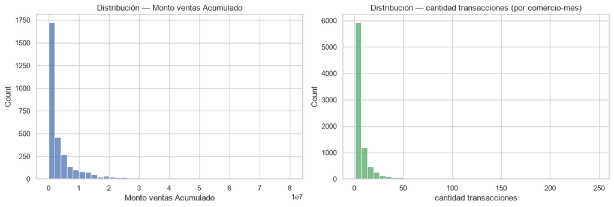

```python
fig, axes = plt.subplots(1, 2, figsize=(13, 4.5))
sns.histplot(df_comercios["Monto ventas Acumulado"], bins=40, ax=axes[0], color="#4C72B0")
axes[0].set_title("Distribución — Monto ventas Acumulado")
sns.histplot(df_transacciones["cantidad transacciones"], bins=40, ax=axes[1], color="#55A868")
axes[1].set_title("Distribución — cantidad transacciones (por comercio-mes)")
plt.tight_layout()
plt.show()
```

### 2.5 Valores atípicos (outliers) e inconsistencias

```python
q1, q3 = df_comercios["Monto ventas Acumulado"].quantile([0.25, 0.75])
iqr = q3 - q1
lim_sup = q3 + 1.5 * iqr
outliers = df_comercios[df_comercios["Monto ventas Acumulado"] > lim_sup]
print(f"Outliers (regla IQR) en Monto Acumulado: {len(outliers)} comercios por encima de {lim_sup:,.0f}")
print(f"Máximo del dataset: {df_comercios['Monto ventas Acumulado'].max():,.0f}")
```

```
Outliers (regla IQR) en Monto Acumulado: 313 comercios por encima de 11,699,000
Máximo del dataset: 80,330,200
```

**Observación:**  
313 comercios (~10%) superan el límite IQR. Es una cola larga esperable en datos de ventas (unos pocos comercios grandes) y no se considera error de datos. Se manejará con log-transformación en el modelado, no se eliminarán.

```python
print("Monto ventas Acumulado <= 0:", (df_comercios["Monto ventas Acumulado"] <= 0).sum())
print("Monto ventas ultimo mes < 0:", (df_comercios["Monto ventas ultimo mes"] < 0).sum())
print("Monto ultimo mes > Monto acumulado (inconsistente):", (df_comercios["Monto ventas ultimo mes"] > df_comercios["Monto ventas Acumulado"]).sum())
```

```
Monto ventas Acumulado <= 0: 21
Monto ventas ultimo mes < 0: 0
Monto ultimo mes > Monto acumulado (inconsistente): 0
```

Se detectan 21 filas (comercios) con `Monto ventas Acumulado <= 0`. Se investiga esto más adelante, porque coinciden con los 21 nulos de `Fecha 1ra_transaccion` vistos arriba.

### 2.6 Tendencia temporal de transacciones

```python
orden_periodos = ["12-2020", "1-2021", "2-2021", "3-2021", "4-2021", "5-2021"]
tendencia = df_transacciones.groupby("mes-anio transaccion").agg(
    comercios_activos=("Id_comercio", "nunique"),
    transacciones=("cantidad transacciones", "sum"),
).reindex(orden_periodos)
tendencia
```

| mes-anio transaccion | comercios_activos | transacciones |
| --- | --- | --- |
| 12-2020 | 198 | 1408 |
| 1-2021 | 353 | 2234 |
| 2-2021 | 887 | 6134 |
| 3-2021 | 2737 | 18205 |
| 4-2021 | 2095 | 17222 |
| 5-2021 | 2087 | 22949 |

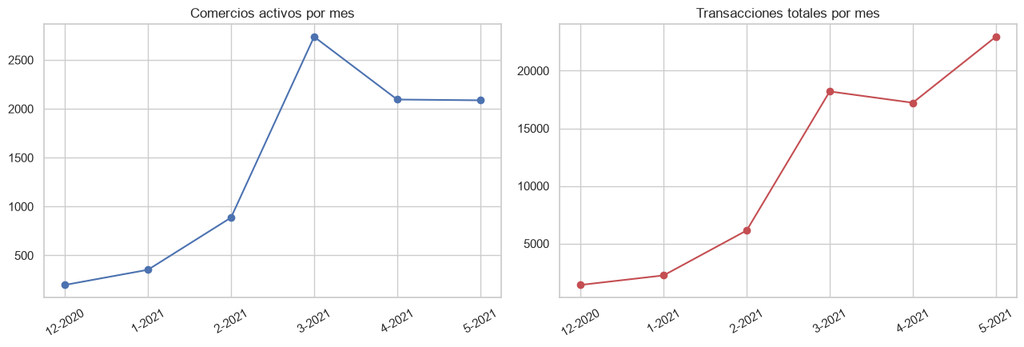

```python
fig, axes = plt.subplots(1, 2, figsize=(13, 4.5))
axes[0].plot(tendencia.index, tendencia["comercios_activos"], marker="o", color="#4C72B0")
axes[0].set_title("Comercios activos por mes"); axes[0].tick_params(axis="x", rotation=30)
axes[1].plot(tendencia.index, tendencia["transacciones"], marker="o", color="#C44E52")
axes[1].set_title("Transacciones totales por mes"); axes[1].tick_params(axis="x", rotation=30)
plt.tight_layout()
plt.show()
```

### 2.7 Correlaciones

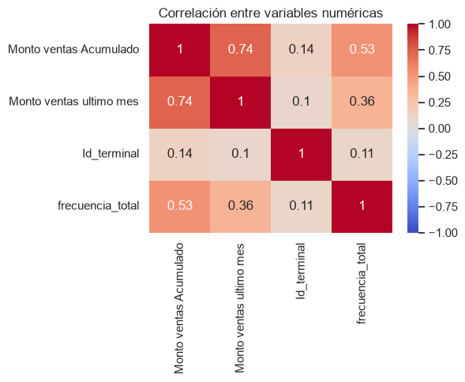

```python
freq_preliminar = df_transacciones.groupby("Id_comercio")["cantidad transacciones"].sum().rename("frecuencia_total")
com_preliminar = df_comercios.groupby("Id_comercio", as_index=False).agg({
    "Monto ventas Acumulado": "sum", "Monto ventas ultimo mes": "sum", "Id_terminal": "nunique"
}).merge(freq_preliminar, on="Id_comercio", how="left")

corr = com_preliminar[["Monto ventas Acumulado", "Monto ventas ultimo mes", "Id_terminal", "frecuencia_total"]].corr()
plt.figure(figsize=(6, 5))
sns.heatmap(corr, annot=True, cmap="coolwarm", vmin=-1, vmax=1)
plt.title("Correlación entre variables numéricas")
plt.tight_layout()
plt.show()
```

- El monto ventas acumulado se correlaciona moderadamente con la frecuencia total (0.53) y fuerte con el monto del último mes (0.74), como es esperable.
- El número de terminales (`Id_terminal` único) casi no esta correlacionado con nada (~0.1) — no parece aportar mucho como variable predictiva por sí sola.

## 3. Calidad de datos: hallazgos, impacto y decisiones

Se documentan aquí, los dos problemas de calidad detectados en el EDA y la decisión tomada para cada uno.

### 3.1 Comercios con múltiples registros (duplicados en `Id_comercio`)

```python
n_filas = len(df_comercios)
n_ids_unicos = df_comercios["Id_comercio"].nunique()
ids_duplicados = df_comercios[df_comercios["Id_comercio"].duplicated(keep=False)]["Id_comercio"].unique()

print(f"Filas totales: {n_filas} | Id_comercio únicos: {n_ids_unicos}")
print(f"Comercios con más de un registro: {len(ids_duplicados)}")
print(f"Filas involucradas: {df_comercios['Id_comercio'].duplicated(keep=False).sum()}")
```

```
Filas totales: 3071 | Id_comercio únicos: 3015
Comercios con más de un registro: 48
Filas involucradas: 104
```

```python
df_comercios.groupby("Id_comercio").size().value_counts().sort_index().rename("Nº de comercios")
```

```
1    2967
2      42
3       5
5       1
Name: Nº de comercios, dtype: int64
```

En la celda anterior vemos, que de los 3015 comercios únicos, 2967 tienen 1 solo registro (normal), pero 48 tienen más de uno (42 con 2 registros, 5 con 3, y 1 con 5).  
Revisemos qué columnas son iguales dentro de cada grupo duplicado y cuáles varían:

```python
dup_rows = df_comercios[df_comercios["Id_comercio"].duplicated(keep=False)].sort_values("Id_comercio")
```

```python
dup_rows
```

|  | Id_comercio | Fecha vinculación datafono | Fecha de creacion comercio | Categoria comercio | Sub Categoria comercio | Id_terminal | Ciudad | Fecha 1ra_transaccion | Monto ventas Acumulado | Monto ventas ultimo mes |
| --- | --- | --- | --- | --- | --- | --- | --- | --- | --- | --- |
| 96 | 15VSQZS9OS | feb. 5, 2021 8:40pm | feb. 5, 2021 8:30pm | Alimentos y bebidas | Comida rápida | 744 | Bogotá D.C. | feb. 5, 2021 8:42pm | 1862800 | 121800 |
| 97 | 15VSQZS9OS | feb. 15, 2021 11:44am | feb. 5, 2021 8:30pm | Alimentos y bebidas | Comida rápida | 730 | Bogotá D.C. | abr. 24, 2021 8:35pm | 3271600 | 1012000 |
| 197 | 266OCTDJC5 | feb. 11, 2021 12:08pm | feb. 9, 2021 3:24pm | Servicios | Logística | 832 | Fusagasugá | feb. 11, 2021 12:12pm | 7210 | 0 |
| 198 | 266OCTDJC5 | feb. 25, 2021 11:00am | feb. 9, 2021 3:24pm | Servicios | Logística | 1871 | Fusagasugá | feb. 25, 2021 11:04am | 2000 | 0 |
| 311 | 3EICTQJZ66 | feb. 20, 2021 4:54pm | feb. 20, 2021 4:42pm | Comercio detallista | Ropa / Accesorios | 1138 | Soacha | feb. 20, 2021 5:01pm | 2000 | 0 |
| ... | ... | ... | ... | ... | ... | ... | ... | ... | ... | ... |
| 2985 | YVIJPP1A0G | mar. 6, 2021 10:42am | ene. 5, 2021 4:19pm | Comercio detallista | Materiales de construcción | 1254 | Soacha | mar. 9, 2021 2:32pm | 3497256 | 0 |
| 3042 | ZMJ7BCK0TN | feb. 25, 2021 1:30pm | feb. 23, 2021 4:41pm | Comercio detallista | Elementos de seguridad | 2738 | Bogotá D.C. | NaN | 0 | 0 |
| 3043 | ZMJ7BCK0TN | feb. 23, 2021 4:50pm | feb. 23, 2021 4:41pm | Comercio detallista | Elementos de seguridad | 2726 | Bogotá D.C. | feb. 23, 2021 4:52pm | 2000 | 0 |
| 3047 | ZNN47AMZMD | feb. 22, 2021 12:57pm | feb. 22, 2021 12:51pm | Comercio detallista | Óptica | 1145 | Bogotá D.C. | feb. 22, 2021 1:01pm | 2000 | 0 |
| 3048 | ZNN47AMZMD | feb. 22, 2021 1:19pm | feb. 22, 2021 12:51pm | Comercio detallista | Óptica | 1146 | Bogotá D.C. | feb. 22, 2021 1:22pm | 2000 | 0 |

104 rows × 10 columns

```python
# Ejemplo: el primer comercio duplicado
ejemplo_id = dup_rows["Id_comercio"].iloc[0]
df_comercios[df_comercios["Id_comercio"] == ejemplo_id]
```

|  | Id_comercio | Fecha vinculación datafono | Fecha de creacion comercio | Categoria comercio | Sub Categoria comercio | Id_terminal | Ciudad | Fecha 1ra_transaccion | Monto ventas Acumulado | Monto ventas ultimo mes |
| --- | --- | --- | --- | --- | --- | --- | --- | --- | --- | --- |
| 96 | 15VSQZS9OS | feb. 5, 2021 8:40pm | feb. 5, 2021 8:30pm | Alimentos y bebidas | Comida rápida | 744 | Bogotá D.C. | feb. 5, 2021 8:42pm | 1862800 | 121800 |
| 97 | 15VSQZS9OS | feb. 15, 2021 11:44am | feb. 5, 2021 8:30pm | Alimentos y bebidas | Comida rápida | 730 | Bogotá D.C. | abr. 24, 2021 8:35pm | 3271600 | 1012000 |

```python
# El caso más extremo: el comercio con 5 registros
id_5_registros = df_comercios.groupby("Id_comercio").size().idxmax()
df_comercios[df_comercios["Id_comercio"] == id_5_registros]
```

|  | Id_comercio | Fecha vinculación datafono | Fecha de creacion comercio | Categoria comercio | Sub Categoria comercio | Id_terminal | Ciudad | Fecha 1ra_transaccion | Monto ventas Acumulado | Monto ventas ultimo mes |
| --- | --- | --- | --- | --- | --- | --- | --- | --- | --- | --- |
| 875 | 9WEPENSRWI | ene. 26, 2021 1:21pm | ene. 21, 2021 4:20pm | Comercio detallista | Muebles / Decoración | 775 | Bogotá D.C. | ene. 26, 2021 1:25pm | 4888373 | 0 |
| 876 | 9WEPENSRWI | mar. 30, 2021 12:26pm | ene. 21, 2021 4:20pm | Comercio detallista | Muebles / Decoración | 2997 | Bogotá D.C. | mar. 30, 2021 12:58pm | 2002000 | 2000000 |
| 877 | 9WEPENSRWI | mar. 30, 2021 12:27pm | ene. 21, 2021 4:20pm | Comercio detallista | Muebles / Decoración | 2995 | Bogotá D.C. | mar. 30, 2021 1:02pm | 2000 | 0 |
| 878 | 9WEPENSRWI | mar. 30, 2021 12:26pm | ene. 21, 2021 4:20pm | Comercio detallista | Muebles / Decoración | 2996 | Bogotá D.C. | mar. 30, 2021 1:10pm | 2000 | 0 |
| 879 | 9WEPENSRWI | mar. 30, 2021 12:27pm | ene. 21, 2021 4:20pm | Comercio detallista | Muebles / Decoración | 2994 | Bogotá D.C. | mar. 30, 2021 1:13pm | 2000 | 0 |

Vamos que, `Categoria`, `Sub Categoria`, `Ciudad` y `Fecha de creación` son idénticas dentro de cada grupo. Lo que varía es `Id_terminal`, las fechas de vinculación/1ra transacción y los montos.  
**Conclusión: no son errores de captura es un mismo comercio con varios datáfonos/terminales**, cada uno con su propio historial.

**Como es el mismo comercio, no tiene sentido dejarlo repartido en varias filas, hay que unirlo en una sola fila por comercio.** Pero no se puede combinar todo igual: cada columna necesita su propia regla:

- **Categoría, Subcategoría, Ciudad, Fecha de creación**: son iguales en todas las filas del grupo, se toma cualquiera (`first`).
- **Monto ventas Acumulado y último mes**: se **suman**, porque son plata real vendida en terminales distintos del mismo negocio.
- **Fecha de vinculación / 1ra transacción**: se toma la **más antigua**, porque representa cuándo el comercio realmente empezó a operar (el primer terminal que se activó).

**Decisión:**  
Se agregan (suman/combinan según la regla de cada columna) los registros duplicados por `Id_comercio`. Adicionalmente se guarda `num_terminales` (cuántos datáfonos tiene el comercio) porque ayuda a diferenciar mejor a los pocos comercios grandes (varios terminales) del resto.

### 3.2 Comercios con `Monto ventas Acumulado = 0` pero con transacciones reales

```python
ids_monto_cero = df_comercios[df_comercios["Monto ventas Acumulado"] <= 0]["Id_comercio"].unique()
tienen_transacciones = df_transacciones[df_transacciones["Id_comercio"].isin(ids_monto_cero)]
print(f"Comercios con Monto Acumulado <= 0: {len(ids_monto_cero)}")
print(f"De esos, cuántos SÍ tienen transacciones registradas: {tienen_transacciones['Id_comercio'].nunique()}")
```

```
Comercios con Monto Acumulado <= 0: 20
De esos, cuántos SÍ tienen transacciones registradas: 20
```

```python
ranking_frecuencia = df_transacciones.groupby("Id_comercio")["cantidad transacciones"].sum().sort_values(ascending=False)
frecuencia_estos = ranking_frecuencia.loc[ranking_frecuencia.index.isin(ids_monto_cero)].sort_values(ascending=False)
frecuencia_estos.head(10)
```

```
Id_comercio
K81AB3YYWE    431
YDR926Y273     35
C2LTJZTRTQ     21
N9P7TD2J70     11
SV3T0W8TD8      6
BC3E6Z902F      5
XTO4EB36AV      4
QEO3J859D2      4
RQ0UEL6O0B      3
MXX4Y9TSGF      2
Name: cantidad transacciones, dtype: int64
```

El caso más extremo: K81AB3YYWE tiene 431 transacciones mientras reporta $0 en monto.

**Esto no son comercios inactivos: es un hueco en el dato de Monto Acumlado.** `Monto ventas Acumulado` viene de la tabla `comercios`, pero si el comercio transaccionó de verdad lo dice la tabla `transacciones`, son dos fuentes distintas que aquí no coinciden. El caso más extremo (`K81AB3YYWE`) tiene 431 transacciones en 6 meses, uno de los comercios más activos de todo el dataset y aun así reporta $0.

Esto importa para el modelo porque como el monto acumulado es una de las 3 variables principales de la segmentación, dejar estos comercios en $0 los mandaría directo al segmento de **menor valor**, cuando por su actividad real de transacciones deberían estar entre los de **mayor valor**. Sería un error de clasificación causado por un dato faltante, no por el comportamiento real del comercio.

**Decisión:**  
No se eliminan (se perderían comercios activos reales) ni se dejan en $0 (clasificarían mal). Se **imputa** un monto estimado: `frecuencia_total del comercio × ticket promedio (mediana) de su categoría`, usando solo comercios con datos válidos para calcular ese ticket. Cada comercio imputado quedará marcado con `monto_imputado = True`, para que la estimación sea trazable, auditable y se pueda filtrar o tratar distinto en el tablero si el cliente lo requiere. Además, es necesario reportar este hueco de datos al equipo de origen.

### 3.3 Inconsistencia de texto en `Ciudad`

```python
print(repr(df_comercios["Ciudad"].value_counts().index[0]))  # revisar espacios ocultos
```

```
'Bogotá  D.C.'
```

`"Bogotá D.C."` tiene doble espacio. No es un error grave, pero se limpia para que Power BI no la trate como texto inconsistente frente a otras fuentes.

## 4. Limpieza y consolidación

```python
# Limpieza de texto (Sección 3.3)
df_comercios["Ciudad"] = df_comercios["Ciudad"].str.strip().str.replace(r"\s+", " ", regex=True)
```

```python
# La decisión de agregar duplicados por Id_comercio (Sección 3.1)
comercios = (
    df_comercios
    .groupby("Id_comercio", as_index=False)
    .agg(
        Categoria_comercio=("Categoria comercio", "first"),
        Sub_categoria_comercio=("Sub Categoria comercio", "first"),
        Ciudad=("Ciudad", "first"),
        Fecha_creacion_comercio=("Fecha de creacion comercio", "first"),
        Fecha_vinculacion_datafono=("Fecha vinculación datafono", "min"),
        Fecha_1ra_transaccion=("Fecha 1ra_transaccion", "min"),
        num_terminales=("Id_terminal", "nunique"),
        Monto_ventas_acumulado=("Monto ventas Acumulado", "sum"),
        Monto_ventas_ultimo_mes=("Monto ventas ultimo mes", "sum"),
    )
)

for col in ["Fecha_creacion_comercio", "Fecha_vinculacion_datafono", "Fecha_1ra_transaccion"]:
    comercios[col] = pd.to_datetime(comercios[col], format="%b. %d, %Y %I:%M%p", errors="coerce")

assert comercios["Id_comercio"].is_unique
print("Comercios después de agregar duplicados:", comercios.shape)
```

```
Comercios después de agregar duplicados: (3015, 10)
```

```python
# La decisión de imputar monto para comercios con Monto=0 pero con transacciones (Sección 3.2)
frecuencia_total_todos = df_transacciones.groupby("Id_comercio")["cantidad transacciones"].sum()

comercios_validos = comercios[comercios["Monto_ventas_acumulado"] > 0].merge(
    frecuencia_total_todos.rename("frecuencia_total"), on="Id_comercio", how="left"
)
comercios_validos["ticket_aprox"] = comercios_validos["Monto_ventas_acumulado"] / comercios_validos["frecuencia_total"].replace(0, np.nan)
ticket_mediano_por_categoria = comercios_validos.groupby("Categoria_comercio")["ticket_aprox"].median()
ticket_mediano_por_categoria
```

```
Categoria_comercio
Alimentos y bebidas            37300.000000
Belleza y cuidado personal     76600.000000
Comercio detallista           174570.588235
Educación                     101757.916667
Reparación y limpieza         159915.413534
Servicios                     153466.764706
Transporte                     23791.666667
Turismo y entretenimiento     106325.500000
Name: ticket_aprox, dtype: float64
```

```python
comercios["monto_imputado"] = False
comercios["Monto_ventas_acumulado"] = comercios["Monto_ventas_acumulado"].astype(float)
ids_a_imputar = comercios[comercios["Monto_ventas_acumulado"] <= 0]["Id_comercio"]

for idc in ids_a_imputar:
    cat = comercios.loc[comercios["Id_comercio"] == idc, "Categoria_comercio"].values[0]
    freq = frecuencia_total_todos.get(idc, 0)
    ticket_cat = ticket_mediano_por_categoria.get(cat, ticket_mediano_por_categoria.median())
    monto_estimado = freq * ticket_cat
    comercios.loc[comercios["Id_comercio"] == idc, "Monto_ventas_acumulado"] = monto_estimado
    comercios.loc[comercios["Id_comercio"] == idc, "monto_imputado"] = True

print(f"Comercios con monto imputado: {comercios['monto_imputado'].sum()}")
comercios[comercios["monto_imputado"]][["Id_comercio", "Categoria_comercio", "Monto_ventas_acumulado", "monto_imputado"]]
```

```
Comercios con monto imputado: 11
```

|  | Id_comercio | Categoria_comercio | Monto_ventas_acumulado | monto_imputado |
| --- | --- | --- | --- | --- |
| 961 | BC3E6Z902F | Comercio detallista | 872852.941176 | True |
| 1162 | DI7S77HE83 | Comercio detallista | 174570.588235 | True |
| 1224 | EAG2VA3X5E | Reparación y limpieza | 159915.413534 | True |
| 1295 | F5T78LFMR3 | Alimentos y bebidas | 37300.000000 | True |
| 1354 | FTSS1Y19KR | Comercio detallista | 174570.588235 | True |
| 1422 | GPEGEY7BX3 | Alimentos y bebidas | 37300.000000 | True |
| 1887 | MAN4695RE8 | Servicios | 153466.764706 | True |
| 1938 | MXX4Y9TSGF | Servicios | 306933.529412 | True |
| 2577 | UR665U2ML7 | Alimentos y bebidas | 37300.000000 | True |
| 2671 | VRXMA745QJ | Servicios | 153466.764706 | True |
| 2849 | XTO4EB36AV | Turismo y entretenimiento | 425302.000000 | True |

## 5. Preparación de `transacciones` y construcción de variables RFM

Vamos a usar un modelo clásico de análisis de clientes (en este caso, comercios) , RFM : **Recencia, Frecuencia y Monto** que resume el comportamiento de cada uno con 3 preguntas:

| Letra | Pregunta que responde | Variable |
| --- | --- | --- |
| **R**ecencia | ¿Hace cuánto fue su última actividad? | `recencia_meses` — meses desde la última transacción hasta mayo-2021 (el mes más reciente) |
| **F**recuencia | ¿Con qué frecuencia transacciona? | `frecuencia_total` (total de transacciones en 6 meses) y `meses_activos` (en cuántos de esos 6 meses tuvo actividad) |
| **M**onto | ¿Cuánto dinero mueve? | `Monto_ventas_acumulado` |

*La lógica de negocio*: un comercio que **transaccionó hace poco** (recencia baja), **transacciona seguido** (frecuencia alta) y **mueve mucho dinero** (monto alto) es probablemente uno de los mejores comercios.

La siguiente celda, convierte `mes-año` que esta tipo texto, a tipo fecha para poder ordenarla y calcular la recencia, y se valida que ningún comercio tenga dos filas en el mismo mes:

```python
def parse_periodo(s):
    mes, anio = s.split("-")
    return pd.Period(year=int(anio), month=int(mes), freq="M")

transacciones = df_transacciones.copy()
transacciones["periodo"] = transacciones["mes-anio transaccion"].apply(parse_periodo)

periodo_max = transacciones["periodo"].max()
periodo_min = transacciones["periodo"].min()
print(f"Periodo de análisis: {periodo_min} a {periodo_max}")
assert transacciones.duplicated(subset=["Id_comercio", "periodo"]).sum() == 0
```

```
Periodo de análisis: 2020-12 a 2021-05
```

La siguiente celda, calcula las 3 variables RFM por comercio a partir de las transacciones, y se unen con la tabla de comercios para tener una sola base lista para segmentar.  
Cada variable se calcula así:

- `frecuencia_total`: se agrupa por `Id_comercio` y se **suma** `cantidad transacciones` de sus 6 meses. Es el total de transacciones del comercio en todo el periodo (la "F" de RFM).
- `meses_activos`: se cuentan los valores **distintos** de `periodo` por comercio (`nunique`). Indica en cuántos de los 6 meses tuvo al menos una transacción.
- `ultimo_periodo` / `primer_periodo` → el mes **máximo** y **mínimo** en que el comercio transaccionó.
- `recencia_meses`: se resta el `ultimo_periodo` de cada comercio al `periodo_max` global (mayo-2021, el mes más reciente del dataset). El resultado (`.n`) es la cantidad de meses de diferencia: 0 si transaccionó en mayo, 3 si su última transacción fue en febrero, etc. Es la "R" de RFM.
- `ticket_promedio`: `Monto_ventas_acumulado` dividido entre `frecuencia_total` (monto total ÷ número de transacciones). No es parte del RFM base, pero lo usaremos como variable adicional para el modelo extendido (sección 7).
- `comision_estimada_5pct`: `Monto_ventas_acumulado` multiplicado por 0.05, la comisión que gana el negocio sobre las ventas de ese comercio. Es la variable que conecta directamente el modelo con el objetivo de negocio del cliente (crecer la comisión un 50% para 2022).
- la "M" de RFM (`Monto_ventas_acumulado`) ya venía calculada desde la sección 4 dentro de `comercios`, mientras que la R y la F se acaban de calcular a partir de `transacciones`.

```python
rfm_trans = transacciones.groupby("Id_comercio").agg(
    frecuencia_total=("cantidad transacciones", "sum"),
    meses_activos=("periodo", "nunique"),
    ultimo_periodo=("periodo", "max"),
    primer_periodo=("periodo", "min"),
).reset_index()
rfm_trans["recencia_meses"] = rfm_trans["ultimo_periodo"].apply(lambda p: (periodo_max - p).n)

data = comercios.merge(rfm_trans, on="Id_comercio", how="inner")
data["ticket_promedio"] = np.where(data["frecuencia_total"] > 0, data["Monto_ventas_acumulado"] / data["frecuencia_total"], 0)
data["comision_estimada_5pct"] = data["Monto_ventas_acumulado"] * 0.05

print("Base final (comercio + RFM):", data.shape)
```

```
Base final (comercio + RFM): (3015, 18)
```

```python
data.head()
```

|  | Id_comercio | Categoria_comercio | Sub_categoria_comercio | Ciudad | Fecha_creacion_comercio | Fecha_vinculacion_datafono | Fecha_1ra_transaccion | num_terminales | Monto_ventas_acumulado | Monto_ventas_ultimo_mes | monto_imputado | frecuencia_total | meses_activos | ultimo_periodo | primer_periodo | recencia_meses | ticket_promedio | comision_estimada_5pct |
| --- | --- | --- | --- | --- | --- | --- | --- | --- | --- | --- | --- | --- | --- | --- | --- | --- | --- | --- |
| 0 | 003QDVFJCJ | Comercio detallista | Ropa / Accesorios | Bogotá D.C. | 2021-03-26 12:17:00 | 2021-03-26 12:40:00 | 2021-03-26 12:42:00 | 1 | 6542000.0 | 1240000 | False | 30 | 3 | 2021-05 | 2021-03 | 0 | 218066.666667 | 327100.0 |
| 1 | 008LJH6YHN | Belleza y cuidado personal | Spa | Bogotá D.C. | 2021-02-10 15:15:00 | 2021-02-10 15:31:00 | 2021-02-10 15:34:00 | 1 | 4380000.0 | 1102000 | False | 10 | 4 | 2021-05 | 2021-02 | 0 | 438000.000000 | 219000.0 |
| 2 | 00B3DGV62G | Comercio detallista | Auto partes | Bogotá D.C. | 2021-03-03 15:09:00 | 2021-03-03 15:26:00 | 2021-03-03 15:30:00 | 1 | 11892500.0 | 1297000 | False | 65 | 3 | 2021-05 | 2021-03 | 0 | 182961.538462 | 594625.0 |
| 3 | 00ILW1BB3Y | Comercio detallista | Tienda naturista | Bogotá D.C. | 2021-03-24 12:33:00 | 2021-03-24 12:45:00 | 2021-03-24 12:51:00 | 1 | 372500.0 | 74500 | False | 8 | 3 | 2021-05 | 2021-03 | 0 | 46562.500000 | 18625.0 |
| 4 | 01AK7UX4UU | Comercio detallista | Tecnología | Mosquera | 2021-03-30 13:40:00 | 2021-03-30 13:50:00 | 2021-03-30 13:52:00 | 1 | 165500.0 | 0 | False | 4 | 2 | 2021-04 | 2021-03 | 1 | 41375.000000 | 8275.0 |

## 6. EDA de las variables RFM

Ahora, graficamos las variables del RFM. Para este caso se usa `log(1+x)` en `frecuencia_total` y `Monto_ventas_acumulado` porque ya habiamos visto que están muy sesgadas y sin el log el histograma muestra una sola barra pegada al cero, sin dejar ver la forma real de la distribución.

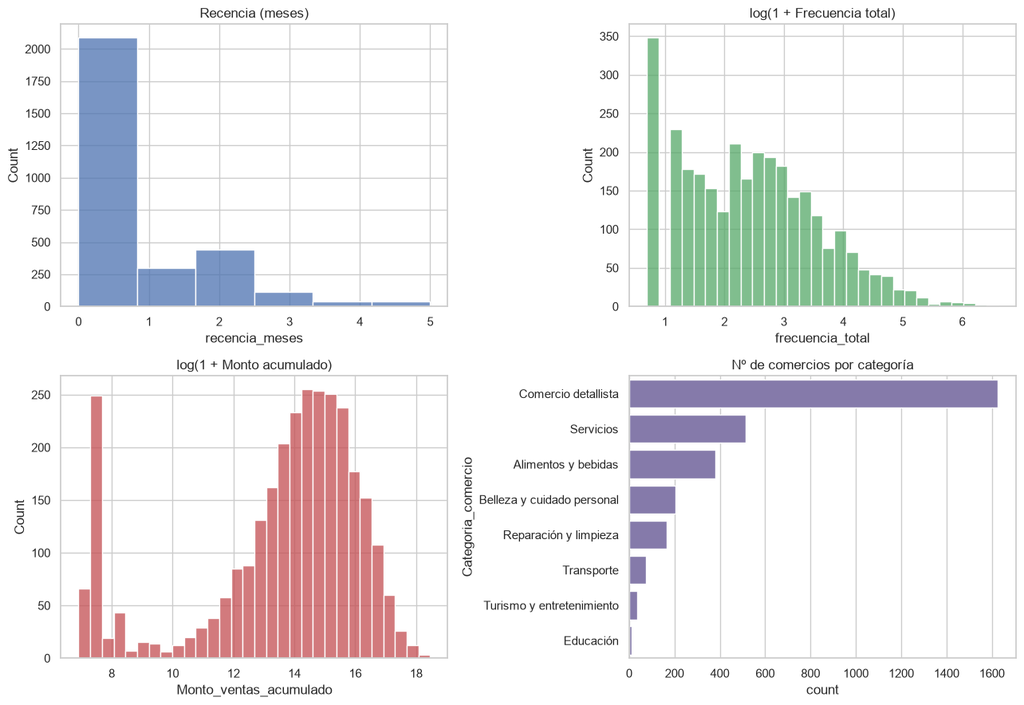

```python
fig, axes = plt.subplots(2, 2, figsize=(13, 9))
sns.histplot(data["recencia_meses"], bins=6, ax=axes[0, 0], color="#4C72B0")
axes[0, 0].set_title("Recencia (meses)")
sns.histplot(np.log1p(data["frecuencia_total"]), bins=30, ax=axes[0, 1], color="#55A868")
axes[0, 1].set_title("log(1 + Frecuencia total)")
sns.histplot(np.log1p(data["Monto_ventas_acumulado"]), bins=30, ax=axes[1, 0], color="#C44E52")
axes[1, 0].set_title("log(1 + Monto acumulado)")
sns.countplot(data=data, y="Categoria_comercio", order=data["Categoria_comercio"].value_counts().index, ax=axes[1, 1], color="#8172B2")
axes[1, 1].set_title("Nº de comercios por categoría")
plt.tight_layout()
plt.show()
```

```python
data[["recencia_meses", "frecuencia_total", "meses_activos", "Monto_ventas_acumulado", "Monto_ventas_ultimo_mes", "ticket_promedio", "num_terminales"]].describe().T
```

|  | count | mean | std | min | 25% | 50% | 75% | max |
| --- | --- | --- | --- | --- | --- | --- | --- | --- |
| recencia_meses | 3015.0 | 6.195688e-01 | 1.080171e+00 | 0.000000 | 0.000000 | 0.000000e+00 | 1.000000e+00 | 5.0 |
| frecuencia_total | 3015.0 | 2.260431e+01 | 4.320107e+01 | 1.000000 | 3.000000 | 1.000000e+01 | 2.300000e+01 | 740.0 |
| meses_activos | 3015.0 | 2.771808e+00 | 1.209754e+00 | 1.000000 | 2.000000 | 3.000000e+00 | 3.000000e+00 | 6.0 |
| Monto_ventas_acumulado | 3015.0 | 4.389116e+06 | 7.785278e+06 | 1000.000000 | 326975.000000 | 1.554000e+06 | 4.976200e+06 | 104180900.0 |
| Monto_ventas_ultimo_mes | 3015.0 | 6.697599e+05 | 1.532529e+06 | 0.000000 | 0.000000 | 1.100000e+05 | 6.824500e+05 | 32650000.0 |
| ticket_promedio | 3015.0 | 2.481366e+05 | 6.350080e+05 | 333.333333 | 40609.155844 | 1.223733e+05 | 3.012307e+05 | 29002000.0 |
| num_terminales | 3015.0 | 1.018574e+00 | 1.597940e-01 | 1.000000 | 1.000000 | 1.000000e+00 | 1.000000e+00 | 5.0 |

## 7. Modelado — comparación de varios enfoques de segmentación

Se prueban 4 enfoques de segmentación para ver cuál funciona mejor:

- **A. Reglas RFM por quintiles** : se divide cada variable en grupos de tamaño igual y se combinan con lógica de negocio. Es el método clásico de marketing.
- **B. K-Means (RFM base)**: clustering real usando solo las 3 variables RFM: agrupa los comercios alrededor de "centros" que se ajustan a los datos.
- **C. K-Means (RFM extendido)**: el mismo algoritmo que B, pero con más variables de comportamiento (`ticket_promedio`, `num_terminales`, `meses_activos`), para ver si separa mejor los segmentos.
- **D. Clustering jerárquico** : en vez de partir de centros, fusiona comercios de a poco según qué tan parecidos son. Sirve de contraste frente a K-Means.

Para comparar qué tan bien separados y compactos quedan los segmentos de cada enfoque, usaremos 3 métricas de calidad de clustering: Silhouette, Davies-Bouldin y Calinski-Harabasz.

### A — Reglas RFM por quintiles

`score_quintil` divide cada variable en 5 grupos de tamaño igual, del peor (1) al mejor (5). Como en recencia un valor bajo es bueno (tuvo transacciones hace poco) y en frecuencia/monto un valor alto es bueno, se invierte el score de recencia (`ascendente=False`) para que las 3 variables queden en la misma escala "1=peor, 5=mejor".  
Los 3 scores se juntan en `RFM_score` (el código clásico de marketing, ej. "555"=mejor comercio posible), y `etiqueta_rfm` traduce esa combinación en una etiqueta de negocio (Campeones, Leales, En riesgo, etc.) con reglas simples. El resultado se guarda en (`segmento_rfm_reglas`).

```python
def score_quintil(serie, ascendente=True):
    rank = serie.rank(method="first")
    q = pd.qcut(rank, 5, labels=[1, 2, 3, 4, 5]).astype(int)
    return q if ascendente else (6 - q)

data["R_score"] = score_quintil(data["recencia_meses"], ascendente=False)
data["F_score"] = score_quintil(data["frecuencia_total"], ascendente=True)
data["M_score"] = score_quintil(data["Monto_ventas_acumulado"], ascendente=True)
data["RFM_score"] = data["R_score"].astype(str) + data["F_score"].astype(str) + data["M_score"].astype(str)

def etiqueta_rfm(row):
    r, f, m = row["R_score"], row["F_score"], row["M_score"]
    if r >= 4 and f >= 4 and m >= 4:
        return "Campeones"
    if r >= 3 and f >= 3:
        return "Leales"
    if r >= 4 and f <= 2:
        return "Nuevos / En crecimiento"
    if r <= 2 and f >= 4:
        return "En riesgo (antes valiosos)"
    if r <= 2 and f <= 2 and m <= 2:
        return "Perdidos / Hibernando"
    return "Potenciales"

data["segmento_rfm_reglas"] = data.apply(etiqueta_rfm, axis=1)
data["segmento_rfm_reglas"].value_counts()
```

```
segmento_rfm_reglas
Leales                        978
Perdidos / Hibernando         736
Campeones                     498
Potenciales                   377
Nuevos / En crecimiento       231
En riesgo (antes valiosos)    195
Name: count, dtype: int64
```

### Preparación común para B, C y D (clustering)

Se preparan dos matrices: `X_base` (solo las 3 de RFM, para B y D) y `X_ext` (RFM + variables extendidas, para C). También se define aquí `mejor_k_operable`, función al elegir el k con mejor Silhouette.

```python
features_base = ["recencia_meses", "frecuencia_total", "Monto_ventas_acumulado"]

features_extendidas = ["recencia_meses", "frecuencia_total", "Monto_ventas_acumulado", "ticket_promedio", "num_terminales", "meses_activos"]

def preparar_matriz(df, cols):
    X = df[cols].copy()
    for c in cols:
        if c != "recencia_meses":
            X[c] = np.log1p(X[c].clip(lower=0))
    return StandardScaler().fit_transform(X)

X_base = preparar_matriz(data, features_base)
X_ext = preparar_matriz(data, features_extendidas)

MIN_SEGMENTOS_NEGOCIO = 3
rango_k = range(2, 11)

def mejor_k_operable(valores_sil, rango, minimo=MIN_SEGMENTOS_NEGOCIO):
    pares = [(k, s) for k, s in zip(rango, valores_sil) if k >= minimo]
    return max(pares, key=lambda t: t[1])[0]
```

### B — K-Means con RFM base

Se corre K-Means probando k de 2 a 10 sobre `X_base` (solo Recencia, Frecuencia, Monto), se mide el Silhouette de cada k, y `mejor_k_operable` elige el mejor entre los que cumplen k≥3. Con ese k final se entrena el modelo y se guarda el segmento de cada comercio en `segmento_kmeans_base`.

```python
sils_base = [silhouette_score(X_base, KMeans(n_clusters=k, random_state=42, n_init=10).fit_predict(X_base)) for k in rango_k]
mejor_k_base = mejor_k_operable(sils_base, rango_k)
kmeans_base = KMeans(n_clusters=mejor_k_base, random_state=42, n_init=10)
data["segmento_kmeans_base"] = kmeans_base.fit_predict(X_base)
print(f"K-Means (RFM base) — mejor k operable: {mejor_k_base} (silhouette={sils_base[list(rango_k).index(mejor_k_base)]:.3f})")
```

```
K-Means (RFM base) — mejor k operable: 3 (silhouette=0.423)
```

### C — K-Means con RFM extendido

Igual que el bloque anterior, pero sobre `X_ext` (RFM + `ticket_promedio`, `num_terminales`, `meses_activos`). El resultado queda en `segmento_kmeans_ext`.

```python
sils_ext = [silhouette_score(X_ext, KMeans(n_clusters=k, random_state=42, n_init=10).fit_predict(X_ext)) for k in rango_k]
mejor_k_ext = mejor_k_operable(sils_ext, rango_k)
kmeans_ext = KMeans(n_clusters=mejor_k_ext, random_state=42, n_init=10)
data["segmento_kmeans_ext"] = kmeans_ext.fit_predict(X_ext)
print(f"K-Means (RFM extendido) — mejor k operable: {mejor_k_ext} (silhouette={sils_ext[list(rango_k).index(mejor_k_ext)]:.3f})")
```

```
K-Means (RFM extendido) — mejor k operable: 3 (silhouette=0.564)
```

### D — Clustering jerárquico (Ward)

Mismo procedimiento de búsqueda de k, pero con `AgglomerativeClustering` sobre `X_base`, para tener un algoritmo de naturaleza distinta a K-Means como contraste. El resultado queda en `segmento_jerarquico`.

```python
sils_jerarquico = [silhouette_score(X_base, AgglomerativeClustering(n_clusters=k, linkage="ward").fit_predict(X_base)) for k in rango_k]
mejor_k_jerarquico = mejor_k_operable(sils_jerarquico, rango_k)
data["segmento_jerarquico"] = AgglomerativeClustering(n_clusters=mejor_k_jerarquico, linkage="ward").fit_predict(X_base)
print(f"Jerárquico (Ward) — mejor k operable: {mejor_k_jerarquico} (silhouette={sils_jerarquico[list(rango_k).index(mejor_k_jerarquico)]:.3f})")
```

```
Jerárquico (Ward) — mejor k operable: 3 (silhouette=0.434)
```

### Comparación de los 4 enfoques

Con los 4 resultados ya calculados (A, B, C, D), armamos una tabla comparativa con las 3 métricas de calidad para decidir cuál usar en la sección 8.

```python
def resumen_metricas(nombre, X, labels):
    return {
        "Enfoque": nombre, "Nº de segmentos": len(set(labels)),
        "Silhouette": round(silhouette_score(X, labels), 3),
        "Davies-Bouldin (↓ mejor)": round(davies_bouldin_score(X, labels), 3),
        "Calinski-Harabasz (↑ mejor)": round(calinski_harabasz_score(X, labels), 1),
    }

codigo_reglas = data["segmento_rfm_reglas"].astype("category").cat.codes
comparacion = pd.DataFrame([
    resumen_metricas("A. RFM por reglas (quintiles)", X_base, codigo_reglas),
    resumen_metricas("B. K-Means (RFM base)", X_base, data["segmento_kmeans_base"]),
    resumen_metricas("C. K-Means (RFM extendido)", X_ext, data["segmento_kmeans_ext"]),
    resumen_metricas("D. Jerárquico / Ward (RFM base)", X_base, data["segmento_jerarquico"]),
]).sort_values("Silhouette", ascending=False)
comparacion
```

|  | Enfoque | Nº de segmentos | Silhouette | Davies-Bouldin (↓ mejor) | Calinski-Harabasz (↑ mejor) |
| --- | --- | --- | --- | --- | --- |
| 2 | C. K-Means (RFM extendido) | 3 | 0.564 | 0.636 | 2431.7 |
| 3 | D. Jerárquico / Ward (RFM base) | 3 | 0.434 | 0.908 | 3308.6 |
| 1 | B. K-Means (RFM base) | 3 | 0.423 | 0.814 | 4105.0 |
| 0 | A. RFM por reglas (quintiles) | 6 | 0.084 | 2.584 | 1230.0 |

## 8. Selección del modelo final y perfilamiento

El enfoque ganador es **C. K-Means (RFM extendido)**, el Silhouette más alto (0.564).

```python
data["segmento_final"] = data["segmento_kmeans_ext"]

orden_valor = data.groupby("segmento_final")["Monto_ventas_acumulado"].mean().sort_values(ascending=False).index.tolist()
etiquetas_por_valor = ["Valor alto", "Valor medio-alto", "Valor medio"]
mapa_etiquetas = {c: etiquetas_por_valor[i] if i < len(etiquetas_por_valor) else f"Segmento {i+1}" for i, c in enumerate(orden_valor)}
data["segmento_final_nombre"] = data["segmento_final"].map(mapa_etiquetas)

perfil = data.groupby("segmento_final_nombre").agg(
    n_comercios=("Id_comercio", "count"),
    recencia_prom=("recencia_meses", "mean"),
    frecuencia_prom=("frecuencia_total", "mean"),
    monto_acum_prom=("Monto_ventas_acumulado", "mean"),
    comision_estimada_total=("comision_estimada_5pct", "sum"),
).round(0).sort_values("comision_estimada_total", ascending=False)
perfil["% comercios"] = (perfil["n_comercios"] / perfil["n_comercios"].sum() * 100).round(1)
perfil["% de comisión total"] = (perfil["comision_estimada_total"] / perfil["comision_estimada_total"].sum() * 100).round(1)
```

```python
data
```

|  | Id_comercio | Categoria_comercio | Sub_categoria_comercio | Ciudad | Fecha_creacion_comercio | Fecha_vinculacion_datafono | Fecha_1ra_transaccion | num_terminales | Monto_ventas_acumulado | Monto_ventas_ultimo_mes | monto_imputado | frecuencia_total | meses_activos | ultimo_periodo | primer_periodo | recencia_meses | ticket_promedio | comision_estimada_5pct | R_score | F_score | M_score | RFM_score | segmento_rfm_reglas | segmento_kmeans_base | segmento_kmeans_ext | segmento_jerarquico | segmento_final | segmento_final_nombre |
| --- | --- | --- | --- | --- | --- | --- | --- | --- | --- | --- | --- | --- | --- | --- | --- | --- | --- | --- | --- | --- | --- | --- | --- | --- | --- | --- | --- | --- |
| 0 | 003QDVFJCJ | Comercio detallista | Ropa / Accesorios | Bogotá D.C. | 2021-03-26 12:17:00 | 2021-03-26 12:40:00 | 2021-03-26 12:42:00 | 1 | 6542000.0 | 1240000 | False | 30 | 3 | 2021-05 | 2021-03 | 0 | 2.180667e+05 | 327100.0 | 5 | 5 | 5 | 555 | Campeones | 2 | 0 | 0 | 0 | Valor medio-alto |
| 1 | 008LJH6YHN | Belleza y cuidado personal | Spa | Bogotá D.C. | 2021-02-10 15:15:00 | 2021-02-10 15:31:00 | 2021-02-10 15:34:00 | 1 | 4380000.0 | 1102000 | False | 10 | 4 | 2021-05 | 2021-02 | 0 | 4.380000e+05 | 219000.0 | 5 | 3 | 4 | 534 | Leales | 0 | 0 | 0 | 0 | Valor medio-alto |
| 2 | 00B3DGV62G | Comercio detallista | Auto partes | Bogotá D.C. | 2021-03-03 15:09:00 | 2021-03-03 15:26:00 | 2021-03-03 15:30:00 | 1 | 11892500.0 | 1297000 | False | 65 | 3 | 2021-05 | 2021-03 | 0 | 1.829615e+05 | 594625.0 | 5 | 5 | 5 | 555 | Campeones | 2 | 0 | 0 | 0 | Valor medio-alto |
| 3 | 00ILW1BB3Y | Comercio detallista | Tienda naturista | Bogotá D.C. | 2021-03-24 12:33:00 | 2021-03-24 12:45:00 | 2021-03-24 12:51:00 | 1 | 372500.0 | 74500 | False | 8 | 3 | 2021-05 | 2021-03 | 0 | 4.656250e+04 | 18625.0 | 5 | 3 | 2 | 532 | Leales | 0 | 0 | 1 | 0 | Valor medio-alto |
| 4 | 01AK7UX4UU | Comercio detallista | Tecnología | Mosquera | 2021-03-30 13:40:00 | 2021-03-30 13:50:00 | 2021-03-30 13:52:00 | 1 | 165500.0 | 0 | False | 4 | 2 | 2021-04 | 2021-03 | 1 | 4.137500e+04 | 8275.0 | 2 | 2 | 1 | 221 | Perdidos / Hibernando | 0 | 0 | 1 | 0 | Valor medio-alto |
| ... | ... | ... | ... | ... | ... | ... | ... | ... | ... | ... | ... | ... | ... | ... | ... | ... | ... | ... | ... | ... | ... | ... | ... | ... | ... | ... | ... | ... |
| 3010 | ZYU8UUM32R | Comercio detallista | Tecnología | Bogotá D.C. | 2021-03-11 11:14:00 | 2021-03-11 11:24:00 | 2021-03-11 11:30:00 | 1 | 26110920.0 | 4912000 | False | 18 | 3 | 2021-05 | 2021-03 | 0 | 1.450607e+06 | 1305546.0 | 2 | 4 | 5 | 245 | En riesgo (antes valiosos) | 2 | 0 | 0 | 0 | Valor medio-alto |
| 3011 | ZYV1ZCZ7IM | Servicios | Tecnología y software | Bogotá D.C. | 2021-03-25 14:36:00 | 2021-03-25 14:46:00 | 2021-03-25 14:47:00 | 1 | 4400500.0 | 491000 | False | 11 | 3 | 2021-05 | 2021-03 | 0 | 4.000455e+05 | 220025.0 | 2 | 3 | 4 | 234 | Potenciales | 0 | 0 | 0 | 0 | Valor medio-alto |
| 3012 | ZZJ3KWF9VC | Alimentos y bebidas | Restaurante / Café | Bogotá D.C. | 2021-03-19 16:00:00 | 2021-03-19 16:09:00 | 2021-03-19 16:12:00 | 1 | 65100.0 | 20000 | False | 5 | 2 | 2021-05 | 2021-03 | 0 | 1.302000e+04 | 3255.0 | 2 | 2 | 1 | 221 | Perdidos / Hibernando | 0 | 0 | 1 | 0 | Valor medio-alto |
| 3013 | ZZMG2NE0Q6 | Comercio detallista | Elementos de seguridad | Bogotá D.C. | 2021-03-12 10:49:00 | 2021-03-12 11:05:00 | 2021-03-12 11:06:00 | 1 | 300000.0 | 149000 | False | 4 | 3 | 2021-05 | 2021-03 | 0 | 7.500000e+04 | 15000.0 | 2 | 2 | 2 | 222 | Perdidos / Hibernando | 0 | 0 | 1 | 0 | Valor medio-alto |
| 3014 | ZZWN25XK8J | Alimentos y bebidas | Restaurante / Café | Choachí | 2021-03-11 15:16:00 | 2021-03-11 15:44:00 | 2021-03-13 17:27:00 | 1 | 1275000.0 | 186500 | False | 50 | 3 | 2021-05 | 2021-03 | 0 | 2.550000e+04 | 63750.0 | 2 | 5 | 3 | 253 | En riesgo (antes valiosos) | 2 | 0 | 0 | 0 | Valor medio-alto |

3015 rows × 28 columns

```python
perfil
```

| segmento_final_nombre | n_comercios | recencia_prom | frecuencia_prom | monto_acum_prom | comision_estimada_total | % comercios | % de comisión total |
| --- | --- | --- | --- | --- | --- | --- | --- |
| Valor medio-alto | 2316 | 0.0 | 28.0 | 5398060.0 | 625095331.0 | 76.8 | 94.5 |
| Valor alto | 48 | 1.0 | 54.0 | 12880024.0 | 30912057.0 | 1.6 | 4.7 |
| Valor medio | 651 | 2.0 | 2.0 | 173634.0 | 5651777.0 | 21.6 | 0.9 |

Los 3 segmentos quedan claramente diferenciados en tamaño y aporte:

- **Valor medio-alto** (2.316 comercios, 76.8% de la base) es el grueso del negocio y genera el 94.5% de la comisión total .
- **Valor alto** (solo 48 comercios, 1.6%) tiene el monto acumulado y la frecuencia promedio más altos de los 3 (más del doble que el segmento anterior), pero por ser tan pocos comercios solo representa el 4.7% de la comisión.
- **Valor medio** (651 comercios, 21.6%) es el segmento con menor actividad (recencia más alta, frecuencia más baja) y aporta apenas 0.9% de la comisión.

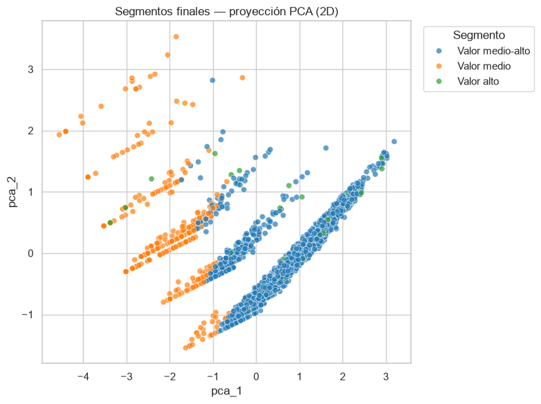

```python
pca = PCA(n_components=2, random_state=42)
coords = pca.fit_transform(X_base)
data["pca_1"], data["pca_2"] = coords[:, 0], coords[:, 1]

plt.figure(figsize=(8, 6))
sns.scatterplot(data=data, x="pca_1", y="pca_2", hue="segmento_final_nombre", palette="tab10", alpha=0.7, s=35)
plt.title("Segmentos finales — proyección PCA (2D)")
plt.legend(title="Segmento", bbox_to_anchor=(1.02, 1), loc="upper left")
plt.tight_layout()
plt.show()
```

Podemos observar, que, "Valor medio-alto" (azul) y "Valor medio" (naranja) se ven como dos brazos diagonales bien diferenciados, lo que confirma que el modelo separa bien estos dos grupos. "Alto valor" (verde) no forma una nube propia y aislada: aparece disperso dentro de las otras dos nubes.

## 9. Construcción de KPIs históricos para seguimiento del objetivo

El objetivo del ejercicio fue segmentar los comercios (secciones 7-8) — el resultado quedó en la columna `segmento_final_nombre` de `data`. Esta sección construye los KPIs de seguimiento usando directamente ese resultado, para responder "¿cómo le está yendo a cada segmento a lo largo del tiempo?".

Los datos no traen el monto en pesos por transacción ni por mes — solo el conteo mensual de transacciones y el monto total acumulado por comercio. Por eso, para tener una serie mensual de comisión, se **estima**: `ticket_promedio` del comercio (monto acumulado ÷ frecuencia total) × transacciones de ese mes × 5%.

### 9.1 Base de estimación: transacciones + resultado del modelo

Se llevan `ticket_promedio`, **`segmento_final_nombre`** (el resultado del modelo, secciones 7-8) y `Categoria_comercio` — que están a nivel *comercio*, en `data` — hacia `transacciones` — que está a nivel *comercio + mes* — con un `merge`. Así cada fila de `transacciones_kpi` queda con el segmento de su comercio, y se calcula `monto_estimado_mes` (transacciones del mes × ticket promedio) y `comision_estimada_mes` (5% de ese monto):

```python
transacciones_kpi = transacciones.merge(
    data[["Id_comercio", "ticket_promedio", "segmento_final_nombre", "Categoria_comercio"]],
    on="Id_comercio", how="left",
)
transacciones_kpi["monto_estimado_mes"] = transacciones_kpi["cantidad transacciones"] * transacciones_kpi["ticket_promedio"]
transacciones_kpi["comision_estimada_mes"] = transacciones_kpi["monto_estimado_mes"] * 0.05
transacciones_kpi["periodo_fecha"] = transacciones_kpi["periodo"].dt.to_timestamp()
transacciones_kpi.head()
```

|  | Id_comercio | mes-anio transaccion | cantidad transacciones | periodo | ticket_promedio | segmento_final_nombre | Categoria_comercio | monto_estimado_mes | comision_estimada_mes | periodo_fecha |
| --- | --- | --- | --- | --- | --- | --- | --- | --- | --- | --- |
| 0 | 003QDVFJCJ | 3-2021 | 5 | 2021-03 | 218066.666667 | Valor medio-alto | Comercio detallista | 1.090333e+06 | 54516.666667 | 2021-03-01 |
| 1 | 003QDVFJCJ | 4-2021 | 9 | 2021-04 | 218066.666667 | Valor medio-alto | Comercio detallista | 1.962600e+06 | 98130.000000 | 2021-04-01 |
| 2 | 003QDVFJCJ | 5-2021 | 16 | 2021-05 | 218066.666667 | Valor medio-alto | Comercio detallista | 3.489067e+06 | 174453.333333 | 2021-05-01 |
| 3 | 008LJH6YHN | 2-2021 | 2 | 2021-02 | 438000.000000 | Valor medio-alto | Belleza y cuidado personal | 8.760000e+05 | 43800.000000 | 2021-02-01 |
| 4 | 008LJH6YHN | 3-2021 | 5 | 2021-03 | 438000.000000 | Valor medio-alto | Belleza y cuidado personal | 2.190000e+06 | 109500.000000 | 2021-03-01 |

### 9.2 KPI general mensual (todo el negocio, sin desagregar)

Se agregan los montos estimados por mes en la nueva tabla `kpi_mensual` — el historial general del negocio. Son 8 KPIs, uno por columna, agrupados en 4 preguntas:

- **Actividad** (¿cuánta gente usa la plataforma?): `comercios_activos` y `transacciones_totales`.
- **Plata** (lo central para el objetivo del cliente): `monto_estimado` y `comision_estimada` — el KPI principal para el objetivo +50%.
- **Promedios** (¿cómo se comporta un comercio típico?): `ticket_promedio_mes` y `frecuencia_promedio_comercio`.
- **Tendencia** (¿va mejorando o empeorando?): `variacion_comision_mom_%` y `comision_acumulada`.

```python
kpi_mensual = transacciones_kpi.groupby("periodo_fecha").agg(
    comercios_activos=("Id_comercio", "nunique"),
    transacciones_totales=("cantidad transacciones", "sum"),
    monto_estimado=("monto_estimado_mes", "sum"),
    comision_estimada=("comision_estimada_mes", "sum"),
).reset_index().sort_values("periodo_fecha")

kpi_mensual["ticket_promedio_mes"] = kpi_mensual["monto_estimado"] / kpi_mensual["transacciones_totales"]
kpi_mensual["frecuencia_promedio_comercio"] = kpi_mensual["transacciones_totales"] / kpi_mensual["comercios_activos"]
kpi_mensual["variacion_comision_mom_%"] = kpi_mensual["comision_estimada"].pct_change().mul(100).round(1)
kpi_mensual["comision_acumulada"] = kpi_mensual["comision_estimada"].cumsum()
kpi_mensual
```

|  | periodo_fecha | comercios_activos | transacciones_totales | monto_estimado | comision_estimada | ticket_promedio_mes | frecuencia_promedio_comercio | variacion_comision_mom_% | comision_acumulada |
| --- | --- | --- | --- | --- | --- | --- | --- | --- | --- |
| 0 | 2020-12-01 | 198 | 1408 | 2.673636e+08 | 1.336818e+07 | 189888.913448 | 7.111111 | NaN | 1.336818e+07 |
| 1 | 2021-01-01 | 353 | 2234 | 5.606460e+08 | 2.803230e+07 | 250960.613236 | 6.328612 | 109.7 | 4.140048e+07 |
| 2 | 2021-02-01 | 887 | 6134 | 1.421008e+09 | 7.105040e+07 | 231660.917026 | 6.915445 | 153.5 | 1.124509e+08 |
| 3 | 2021-03-01 | 2737 | 18205 | 3.740350e+09 | 1.870175e+08 | 205457.312069 | 6.651443 | 163.2 | 2.994684e+08 |
| 4 | 2021-04-01 | 2095 | 17222 | 3.089805e+09 | 1.544903e+08 | 179410.372504 | 8.220525 | -17.4 | 4.539587e+08 |
| 5 | 2021-05-01 | 2087 | 22949 | 4.154010e+09 | 2.077005e+08 | 181010.494747 | 10.996167 | 34.4 | 6.616592e+08 |

### 9.3 Seguimiento del objetivo de negocio (+50% de comisión para 2022)

Se toma el mes más reciente (mayo-2021) como línea base y se traza la meta: comisión mensual 50% más alta al cierre de 2022. Es una proyección simple lineal solo para dar una referencia visual.

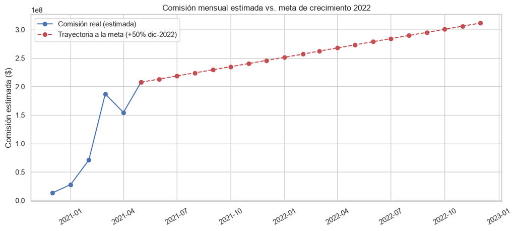

```
Comisión base (may-2021): $207,700,492
Meta a dic-2022 (+50%): $311,550,738
```

```python
base_comision = kpi_mensual["comision_estimada"].iloc[-1]
meta_comision_2022 = base_comision * 1.5
meses_a_meta = 19  # de mayo-2021 a dic-2022

fechas_proyeccion = pd.date_range(kpi_mensual["periodo_fecha"].iloc[-1], periods=meses_a_meta + 1, freq="MS")
comision_proyectada = np.linspace(base_comision, meta_comision_2022, meses_a_meta + 1)
proyeccion = pd.DataFrame({"periodo_fecha": fechas_proyeccion, "comision_meta_lineal": comision_proyectada})

fig, ax = plt.subplots(figsize=(11, 5))
ax.plot(kpi_mensual["periodo_fecha"], kpi_mensual["comision_estimada"], marker="o", label="Comisión real (estimada)", color="#4C72B0")
ax.plot(proyeccion["periodo_fecha"], proyeccion["comision_meta_lineal"], linestyle="--", marker="o", label="Trayectoria a la meta (+50% dic-2022)", color="#C44E52")
ax.set_title("Comisión mensual estimada vs. meta de crecimiento 2022")
ax.set_ylabel("Comisión estimada ($)")
ax.legend()
plt.xticks(rotation=30)
plt.tight_layout()
plt.show()

print(f"Comisión base (may-2021): ${base_comision:,.0f}")
print(f"Meta a dic-2022 (+50%): ${meta_comision_2022:,.0f}")
```

### 9.4 KPI mensual por segmento — el resultado directo de la segmentación

Igual que 9.2, pero agrupando también por `segmento_final_nombre`. Esta es la tabla que conecta directamente el modelo de segmentación con el seguimiento del objetivo: permite ver, mes a mes, si el crecimiento de la comisión depende cada vez más de un segmento u otro.

```python
kpi_mensual_segmento = transacciones_kpi.groupby(["periodo_fecha", "segmento_final_nombre"]).agg(
    comercios_activos=("Id_comercio", "nunique"),
    transacciones=("cantidad transacciones", "sum"),
    comision_estimada=("comision_estimada_mes", "sum"),
).reset_index().sort_values(["segmento_final_nombre", "periodo_fecha"])

kpi_mensual_segmento["% comisión del mes"] = (
    kpi_mensual_segmento["comision_estimada"]
    / kpi_mensual_segmento.groupby("periodo_fecha")["comision_estimada"].transform("sum") * 100
).round(1)

pivot_comision = kpi_mensual_segmento.pivot(index="periodo_fecha", columns="segmento_final_nombre", values="comision_estimada")
pivot_comision
```

| segmento_final_nombre periodo_fecha | Valor alto | Valor medio | Valor medio-alto |
| --- | --- | --- | --- |
| 2020-12-01 | 1.627540e+06 | 1.136289e+06 | 1.060435e+07 |
| 2021-01-01 | 3.214719e+06 | 9.064167e+05 | 2.391116e+07 |
| 2021-02-01 | 6.982425e+06 | 8.945606e+05 | 6.317342e+07 |
| 2021-03-01 | 7.749626e+06 | 2.635352e+06 | 1.766325e+08 |
| 2021-04-01 | 4.931815e+06 | 6.950348e+04 | 1.494890e+08 |
| 2021-05-01 | 6.405933e+06 | 9.655774e+03 | 2.012849e+08 |

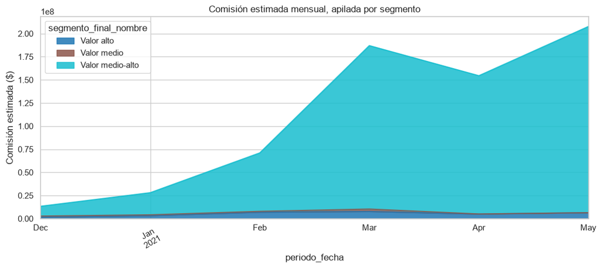

```python
pivot_comision.plot(kind="area", stacked=True, figsize=(11, 5), colormap="tab10", alpha=0.85)
plt.title("Comisión estimada mensual, apilada por segmento")
plt.ylabel("Comisión estimada ($)")
plt.xticks(rotation=30)
plt.tight_layout()
plt.show()
```

### 9.5 KPI mensual por categoría

Mismo cálculo que 9.4, pero agrupando por `Categoria_comercio` en vez de por segmento — para ver cuáles categorías de comercio están impulsando (o frenando) el crecimiento de la comisión mes a mes.

```python
kpi_mensual_categoria = transacciones_kpi.groupby(["periodo_fecha", "Categoria_comercio"]).agg(
    comercios_activos=("Id_comercio", "nunique"),
    transacciones=("cantidad transacciones", "sum"),
    comision_estimada=("comision_estimada_mes", "sum"),
).reset_index().sort_values(["Categoria_comercio", "periodo_fecha"])

kpi_mensual_categoria["% comisión del mes"] = (
    kpi_mensual_categoria["comision_estimada"]
    / kpi_mensual_categoria.groupby("periodo_fecha")["comision_estimada"].transform("sum") * 100
).round(1)

pivot_categoria = kpi_mensual_categoria.pivot(index="periodo_fecha", columns="Categoria_comercio", values="comision_estimada")
pivot_categoria
```

| Categoria_comercio periodo_fecha | Alimentos y bebidas | Belleza y cuidado personal | Comercio detallista | Educación | Reparación y limpieza | Servicios | Transporte | Turismo y entretenimiento |
| --- | --- | --- | --- | --- | --- | --- | --- | --- |
| 2020-12-01 | 4.161198e+05 | 1.588913e+06 | 5.379387e+06 | NaN | 8.212731e+05 | 5.015679e+06 | 1.174141e+04 | 1.350667e+05 |
| 2021-01-01 | 8.493298e+05 | 1.471227e+06 | 1.557653e+07 | 792.500000 | 3.288671e+06 | 6.761802e+06 | 1.160389e+04 | 7.234833e+04 |
| 2021-02-01 | 4.749242e+06 | 4.889680e+06 | 4.410407e+07 | 108003.571429 | 3.906224e+06 | 1.150909e+07 | 1.133217e+05 | 1.670764e+06 |
| 2021-03-01 | 1.367583e+07 | 8.136186e+06 | 1.207506e+08 | 907681.626623 | 9.824681e+06 | 2.980876e+07 | 1.405087e+06 | 2.508653e+06 |
| 2021-04-01 | 1.581575e+07 | 6.649079e+06 | 9.579782e+07 | 488016.894481 | 7.932102e+06 | 2.365999e+07 | 1.835480e+06 | 2.312037e+06 |
| 2021-05-01 | 2.096395e+07 | 1.000260e+07 | 1.323891e+08 | 706781.657468 | 9.518322e+06 | 2.950524e+07 | 2.310131e+06 | 2.304325e+06 |

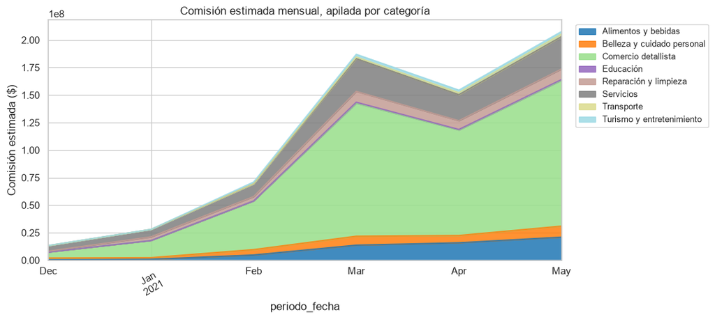

```python
pivot_categoria.plot(kind="area", stacked=True, figsize=(11, 5), colormap="tab20", alpha=0.85)
plt.title("Comisión estimada mensual, apilada por categoría")
plt.ylabel("Comisión estimada ($)")
plt.legend(bbox_to_anchor=(1.02, 1), loc="upper left", fontsize=9)
plt.xticks(rotation=30)
plt.tight_layout()
plt.show()
```

## 10. Exportación de datos para Power BI

Vamos a exportar todas las tablas anteriormente calculadas para el desarrollo del tablero en PowerBI:

```python
import os
os.makedirs("powerbi", exist_ok=True)

cols_export = [
    "Id_comercio", "Categoria_comercio", "Sub_categoria_comercio", "Ciudad",
    "Fecha_creacion_comercio", "Fecha_vinculacion_datafono", "Fecha_1ra_transaccion",
    "num_terminales", "Monto_ventas_acumulado", "Monto_ventas_ultimo_mes", "monto_imputado",
    "ticket_promedio", "comision_estimada_5pct", "recencia_meses", "frecuencia_total", "meses_activos",
    "R_score", "F_score", "M_score", "RFM_score", "segmento_rfm_reglas",
    "segmento_kmeans_base", "segmento_kmeans_ext", "segmento_jerarquico",
    "segmento_final", "segmento_final_nombre",
]
data[cols_export].to_csv("powerbi/comercios_segmentados.csv", index=False, encoding="utf-8-sig")

transacciones_export = transacciones_kpi.merge(
    data[["Id_comercio", "Ciudad"]], on="Id_comercio", how="left"
)
cols_transacciones = [
    "Id_comercio", "periodo_fecha", "Categoria_comercio", "Ciudad", "segmento_final_nombre",
    "cantidad transacciones", "ticket_promedio", "monto_estimado_mes", "comision_estimada_mes",
]
transacciones_export[cols_transacciones].to_csv("powerbi/transacciones_mensual.csv", index=False, encoding="utf-8-sig")

resumen_mensual = transacciones.groupby("periodo").agg(
    comercios_activos=("Id_comercio", "nunique"), transacciones_totales=("cantidad transacciones", "sum")
).reset_index()
resumen_mensual["periodo_fecha"] = resumen_mensual["periodo"].dt.to_timestamp()
resumen_mensual.drop(columns=["periodo"]).to_csv("powerbi/resumen_kpis_mensual.csv", index=False, encoding="utf-8-sig")

comparacion.to_csv("powerbi/comparacion_modelos_segmentacion.csv", index=False, encoding="utf-8-sig")
perfil.reset_index().to_csv("powerbi/perfil_segmentos.csv", index=False, encoding="utf-8-sig")

kpi_mensual.to_csv("powerbi/kpis_mensuales.csv", index=False, encoding="utf-8-sig")
proyeccion.to_csv("powerbi/proyeccion_meta_2022.csv", index=False, encoding="utf-8-sig")
kpi_mensual_segmento.to_csv("powerbi/kpis_mensuales_por_segmento.csv", index=False, encoding="utf-8-sig")
kpi_mensual_categoria.to_csv("powerbi/kpis_mensuales_por_categoria.csv", index=False, encoding="utf-8-sig")

print("Archivos exportados en 'powerbi/':")
for f in os.listdir("powerbi"):
    print(" -", f)
```

```
Archivos exportados en 'powerbi/':
 - comercios_segmentados.csv
 - comparacion_modelos_segmentacion.csv
 - kpis_mensuales.csv
 - kpis_mensuales_por_categoria.csv
 - kpis_mensuales_por_segmento.csv
 - perfil_segmentos.csv
 - proyeccion_meta_2022.csv
 - resumen_kpis_mensual.csv
 - transacciones_mensual.csv
```

## 11. Respuestas a los 3 puntos del ejercicio

### a. Modelo de segmentación implementado y resultados

Sobre la base ya limpia se construyó un modelo **RFM** y se compararon 4 enfoques de segmentación (reglas por quintiles, K-Means con dos conjuntos de variables, y clustering jerárquico), seleccionando el de mejor desempeño estadístico (Silhouette, Davies-Bouldin, Calinski-Harabasz). El resultado asigna a cada uno de los 3,015 comercios activos un segmento de valor.

### b. KPIs y métricas recomendadas — calculados, no solo enunciados

Se agrupan en las mismas 4 categorías de la sección 9.2, más una quinta de segmentación:

- **Actividad** (¿cuánta gente usa la plataforma?): número de comercios activos por mes y frecuencia promedio por comercio (tabla `kpi_mensual`).
- **Plata** (lo central para el objetivo del cliente): comisión mensual estimada (5% del monto transaccionado) y el monto total movido cada mes (tabla `kpi_mensual`); comparación contra la trayectoria de la meta +50% para diciembre 2022 (tabla `proyeccion`).
- **Promedios** (¿cómo se comporta un comercio típico?): ticket promedio del mes (tabla `kpi_mensual`).
- **Tendencia** (¿va mejorando o empeorando?): cuánto sube o baja la comisión respecto al mes anterior, y la comisión acumulada desde diciembre 2020 (tabla `kpi_mensual`).
- **Segmentación** (el cruce que pide el cliente): comisión y comercios activos por mes, desglosados por el segmento de valor de cada comercio (tabla `kpi_mensual_segmento`), incluyendo qué % aporta cada segmento a la comisión total de cada mes — permite ver si "Alto valor" está creciendo o si el negocio depende cada vez más del segmento medio.

### c. Tablero

Las tres tablas de KPIs (`kpi_mensual`, `kpi_mensual_segmento`, `proyeccion`) más `comercios_segmentados` son la base directa del tablero: evolución mensual de comisión y comercios activos, comisión apilada por segmento, comparación contra la meta 2022, y mix/perfil de segmentos.